# Network statistics

Day 21

## Statistical Analysis of networks

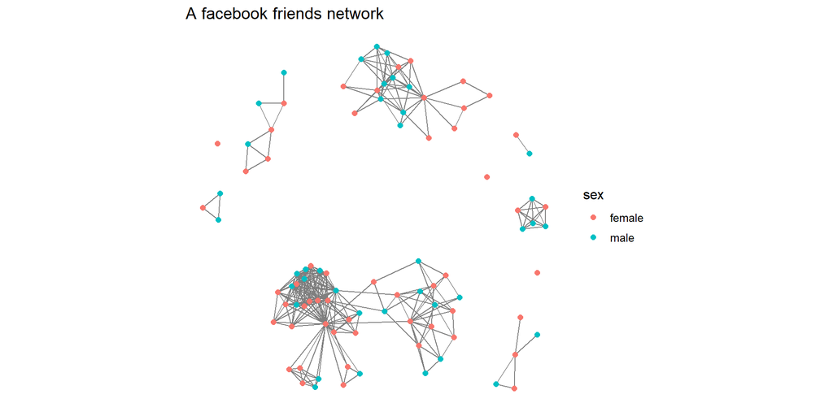

## Statistical Analysis of networks

- Imminent Brewery FB page: post “likers” connected if they like the same post

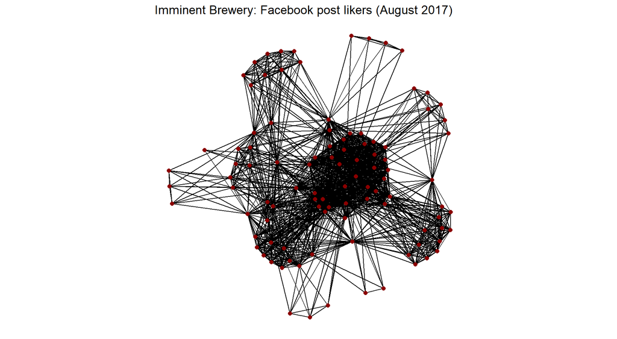

## Simple example

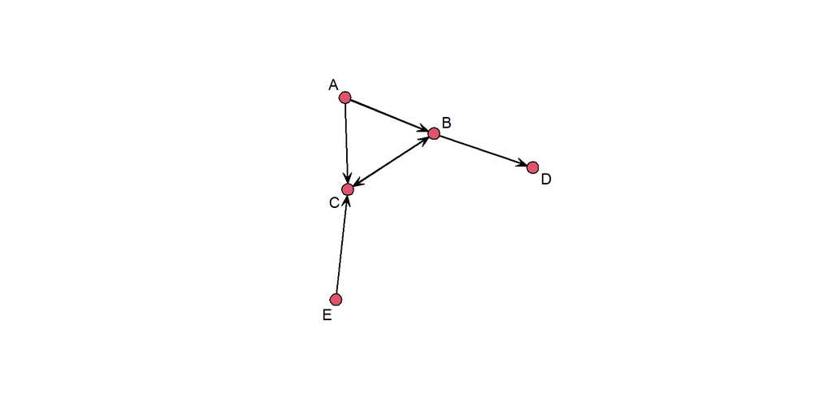

## Simpsons network

- 15 Simpsons characters with undirected edges defined for characters who interact “a lot”

[figure not shown]

## Summary Stats for Networks

- For most quantitative variables, we can compute summary statistics that inform
  - center (mean, median)
  - spread (sd, IQR, range)
  - skew (quartiles, percentiles)
- We came compute similar stats for data from nodes or edges
  - e.g. proportion of females in facebook nodes
- Stats can also be used to describe a network’s relational data
  - node and edge stats: related to relationships
  - Overall network stats: size, density, clustering, …
  - unless stated otherwise, we will assume undirected networks

## Node statistics

- **Centrality** stats help assess the *prominence* or *importance* of each node in the network
  - **Degree** - tells us how many edges each node has
  - **Betweenness** - tells us how many important paths cross through that node
  - **Closeness** - tells us how close a node is to other points
  - nodes that stand out with high levels of centrality are the “key players”
- We can use *summaries* of node-level stats to describe the entire network
  - e.g look at average degree, or the distribution of degree across all nodes

## Node statistics: degree

- **Degree**: number of edges connected to a vertex
  - directed networks: in, out and total degree counts
- Here we use `degree` from the `sna` package
  - `sna::degree(network, gmode=)` with gmode `digraph` for directed graphs (default) and `graph` for undirected

## Node statistics: degree

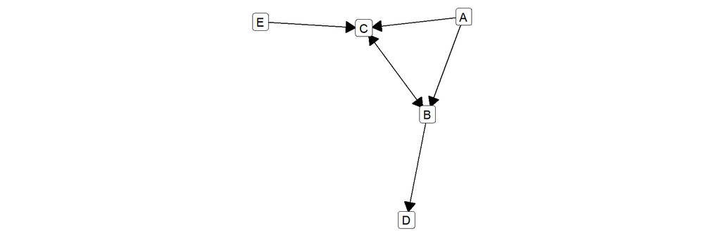

```r
> sna::degree(mynet) # total degree
[1] 2 4 4 1 1
> sna::degree(mynet, cmode="indegree") # number edges in
[1] 0 2 3 1 0
> sna::degree(mynet, cmode="outdegree") # number edges out
[1] 2 2 1 0 1
```

## Node statistics: degree

- Add degree as a network node variable

```r
> (deg_S <- sna::degree(Simpsons, gmode="graph") )
 [1] 8 4 8 5 3 2 1 2 2 3 3 3 2 1 1
> Simpsons %v% "vertex.names"
 [1] "Homer"        "Marge"        "Bart"         "Lisa"         "Maggie"
 [6] "Mr. Burns"    "Smithers"     "Pr. Skinner"  "Gr. Willie"   "Carl"
[11] "Lenny"        "Moe"          "Milhouse"     "Ralph Wiggum" "Ned Flanders"
> set.vertex.attribute(Simpsons, "degree", deg_S)
```

- then vary node size by degree

## Node statistics: degree

[figure not shown]

## Node statistics: betweeness

- **Betweenness**: measures the extent to which a node sits “between” pairs of other nodes.
  - a high level of betweenness means that a node is in a position to control the flow of “information” in a network

\[ Between(v)= \sum_{s,t\in V\setminus\{v\}}\frac{\sigma_v(s,t)}{\sigma(s,t)} \] - \(\sigma(s,t)\) # of shortest paths from \(s\) to \(t\)  
- \(\sigma_v(s,t)\) # of shortest paths from \(s\) to \(t\) that pass through \(v\)

## Node statistics: betweeness

- How does degree and betweneess differ?

[figure not shown]

## Node statistics: closeness

- **Closeness**: measures how close a node is to all other nodes in the network
  - a high level of closeness means that only a few steps are needed to get to all other nodes in the network

\[ Close(v)= \frac{1}{avg \ dist}= \frac{1}{\frac{\sum_{i\neq v}{d(v,i)}}{N-1}}= \frac{N-1}{\sum_{i\neq v}{d(v,i)}} \]

- \(d(v,i)\): shortest distance between \(v\) and \(i\)
- \(N\): the number of nodes

## Node statistics: closeness

- Gives you a better sense of distance than betweeness (see Smithers)

[figure not shown]

## Comparing networks via node statistics

- You can treat these node stats like any other type of data
- Compare within a network to find unusual cases
  - “central” players
- Compare across networks to compare relational structures
  - may make sense to standardize values to compare extremeness nodes

## Comparing degree

- All three networks have at least one high outlier, but different degree scales (different number of nodes)

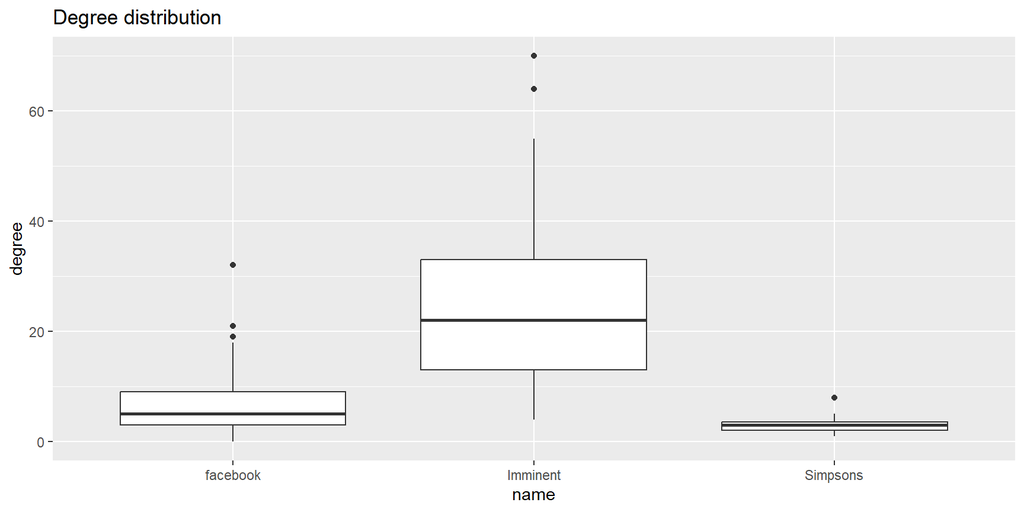

## Comparing degree

- Highest degree in facebook is over 4 SD’s above mean while the largest in Simpsons is just over 2 SD’s above.

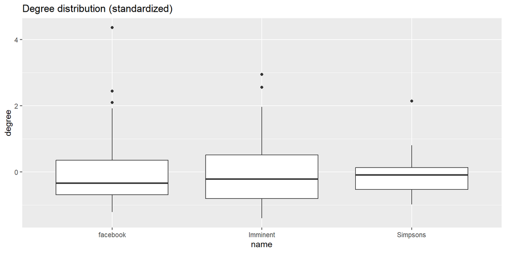

## Comparing betweenness

- Imminent has the most extreme betweenness

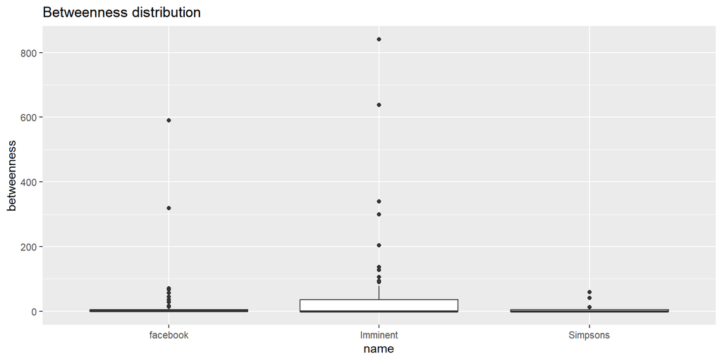

## Comparing betweenness

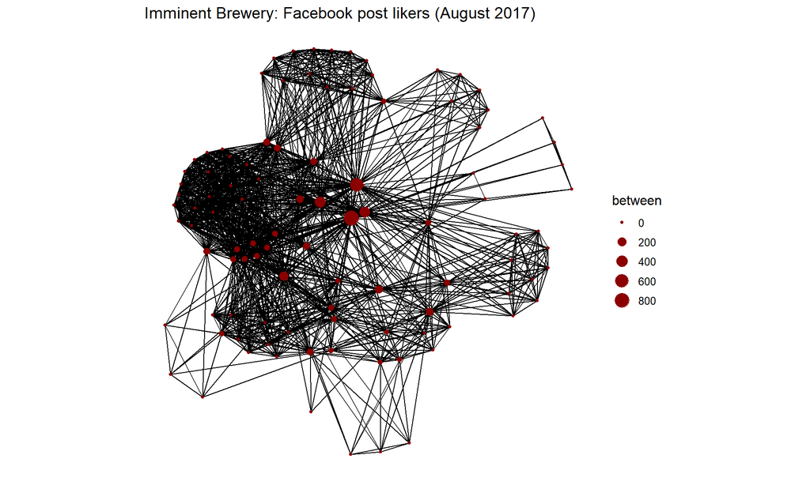

## Network level statistics

- Some stats describe features of the entire network’s relational structure
  - size, number of subcomponents
  - diameter
  - density
  - transitivity (cluster)

## Network level statistics: Size

- **Size**: how many vertices?

```r
> network.size(mynet)
[1] 5
> network.size(facebook)
[1] 93
> network.size(facebookImm_Aug)
[1] 101
```

## Network level statistics: Subgroups

- **Number of subgroups**: how many subgroups (connected networks), or components, in undirected networks

```r
> num_compF <- components(facebook)
> num_compImm <- components(facebookImm_Aug)
```

```r
> num_compF
[1] 10
> num_compImm
[1] 1
```

There are 10 subgroups in the facebook friends network and one in the Imminent network

## Network level statistics: Subgroups

```r
> comp_distF <- component.dist(facebook)
```

```r
> comp_distF$membership[1:10]
 [1] 1 1 1 1 1 2 2 3 3 3
> comp_distF$csize
 [1] 47  2 20  3  7  6  5  1  1  1
> comp_distF$cdist[1:10]
 [1] 3 1 1 0 1 1 1 0 0 0
```

- The largest subgraph has 47 nodes.
- There are 3 subgraphs of size one, 1 of size two, etc.

## Network level statistics: Diameter

- **Diameter**: max of the shortest paths across all node pairs
  - max of the largest component
  - measures the compactness of a networks
  - easiest way to get diameter is with `igraph`

```r
> igraph::diameter(asIgraph(facebook))  # diameter
[1] 4
> igraph::diameter(asIgraph(facebookImm_Aug))  # diameter
[1] 3
> igraph::diameter(asIgraph(Simpsons))  # diameter
[1] 4
```

Both facebook and Simpons networks only takes at most 4 steps to connect any two nodes, while the Imminent network takes just 3 steps

## Network level statistics: Diameter

- Diameter seems low but central nodes that connect the graph pretty well

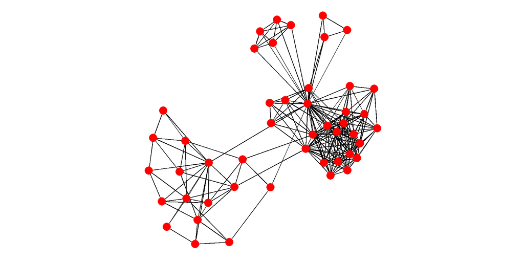

## Network level statistics: Density

- **Density**: proportion of edges observed in the network to the max number possible
- Let \(T\) be the number of ties (edges) in the network with \(n\) vertices \[ den_{directed} = \dfrac{T}{n(n-1)} \ \ \ den_{undirected} = \dfrac{2T}{n(n-1)} \]

```r
> network.edgecount(facebook); gden(facebook)
[1] 323
[1] 0.07550257
> network.edgecount(facebookImm_Aug); gden(facebookImm_Aug)
[1] 1274
[1] 0.2522772
```

Imminent network has higher density even though network sizes are similar.

## Network level statistics: Transitivity

- **Transitivity** is the proportion of closed triangles in the networked to the total number of (open and closed) triangles \[ Transitivity = \dfrac{3 \times \textrm{# triangles}}{\textrm{# connected triples}} \]
  - common measure of network **clustering**
  - are your friends also my friends?

```r
> gtrans(facebook)
[1] 0.6662791
> gtrans(facebookImm_Aug)
[1] 0.7128538
```

Slightly higher clustering in the Imminent network